# Session 4: GAM Practical I

Multiple smooth terms, prediction and diagnostics

Oscar Rodriguez de Rivera | University of Exeter

```r
library(tidyverse)
library(mgcv)

theme_set(theme_minimal(base_size = 12))
```

# 1 Session overview

## 1.1 Aim

This practical builds on the introduction to Generalised Additive Models.

In the previous document, we fitted a GAM with one smooth term. Here, we move closer to realistic ecological and environmental modelling by fitting a GAM with several covariates.

The aim is to understand how GAMs can model several nonlinear relationships at the same time.

The workflow is:

1. explore the response and covariates;
2. fit a linear model as a baseline;
3. fit a GAM with several smooth terms;
4. check model diagnostics;
5. visualise partial effects;
6. use predictions to interpret the fitted model.

## 1.2 Why this matters

In applied ecology and environmental science, responses often depend on several continuous variables at once.

For example:

- species abundance may depend on temperature, rainfall, elevation and habitat structure;
- air pollution may depend on time, weather, traffic and spatial location;
- wildfire risk may depend on vegetation, weather, topography and season;
- disease risk may depend on temperature, humidity and host density.

In many cases, these relationships are not straight lines.

A GAM lets us model nonlinear effects while keeping the regression framework familiar.

## 1.3 Learning outcomes

By the end of this practical, students should be able to:

- fit a GAM with several smooth terms;
- compare a linear model and a GAM;
- interpret the smooth terms in a GAM summary;
- use diagnostic plots to assess model fit;
- produce partial prediction plots;
- explain nonlinear covariate effects in applied language;
- understand why predictions are central to GAM interpretation.

# 2 Simulated ecological data

## 2.1 Why use simulated data?

In this practical we use `mgcv::gamSim()`.

This gives us a reproducible dataset with known nonlinear structure. It avoids dependence on local data files and allows everyone to run the same analysis.

The dataset is artificial, but it behaves like many ecological datasets: one response variable is influenced by several continuous covariates.

```r
set.seed(234)

gam_dat <- mgcv::gamSim(
  eg = 1,
  n = 400,
  dist = "normal",
  scale = 2,
  verbose = FALSE
) %>%
  as_tibble()

dplyr::glimpse(gam_dat)
```

```
## Rows: 400
## Columns: 10
## $ y  <dbl> 4.0573977, 9.2713672, 3.2835655, 9.3472783, 7.6267987, 10.7811590, …
## $ x0 <dbl> 0.745619998, 0.781712425, 0.020037114, 0.776085387, 0.066910093, 0.…
## $ x1 <dbl> 0.02885590, 0.93745388, 0.79777294, 0.66797951, 0.59740948, 0.01351…
## $ x2 <dbl> 0.874802216, 0.703993423, 0.951583363, 0.478099873, 0.533240392, 0.…
## $ x3 <dbl> 0.93319087, 0.40177800, 0.08742998, 0.89302195, 0.10244557, 0.88236…
## $ f  <dbl> 2.669810, 10.636772, 5.058326, 7.941538, 6.514449, 11.728775, 5.245…
## $ f0 <dbl> 1.433538903, 1.266539247, 0.125813772, 1.293702822, 0.417319332, 1.…
## $ f1 <dbl> 1.059410, 6.520218, 4.931020, 3.803642, 3.302960, 1.027395, 1.54681…
## $ f2 <dbl> 0.176861791, 2.850015471, 0.001492496, 2.844193315, 2.794169607, 8.…
## $ f3 <dbl> 0, 0, 0, 0, 0, 0, 0, 0, 0, 0, 0, 0, 0, 0, 0, 0, 0, 0, 0, 0, 0, 0, 0…
```

The response variable is `y`.

The covariates are:

- `x0`;
- `x1`;
- `x2`;
- `x3`.

Each covariate may have a different relationship with the response.

# 3 Explore the data

## 3.1 Response distribution

Before fitting a model, we should inspect the response.

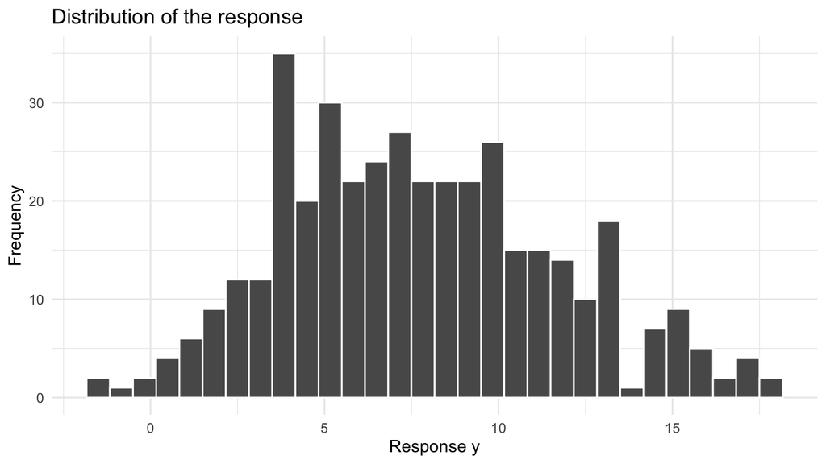

```r
ggplot(gam_dat, aes(x = y)) +
  geom_histogram(bins = 30, colour = "white") +
  labs(
    title = "Distribution of the response",
    x = "Response y",
    y = "Frequency"
  )
```

This plot helps us check the scale and spread of the response.

Here the response is continuous and approximately suitable for a Gaussian model.

## 3.2 Response against each covariate

A useful first step is to plot the response against each predictor.

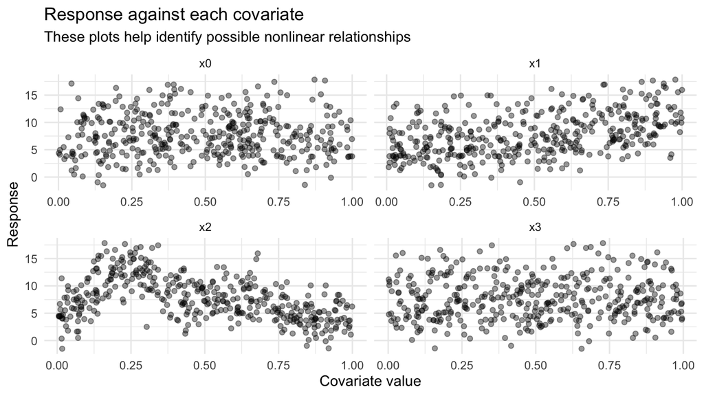

```r
gam_dat %>%
  tidyr::pivot_longer(
    cols = tidyselect::starts_with("x"),
    names_to = "covariate",
    values_to = "value"
  ) %>%
  ggplot(aes(x = value, y = y)) +
  geom_point(alpha = 0.4) +
  facet_wrap(~ covariate, scales = "free_x") +
  labs(
    x = "Covariate value",
    y = "Response",
    title = "Response against each covariate",
    subtitle = "These plots help identify possible nonlinear relationships"
  )
```

## 3.3 Interpreting the exploratory plots

The scatterplots show whether each covariate may be related to the response.

Some relationships may look curved. Others may look weak or noisy.

This is common in applied data: not every covariate has the same type or strength of relationship with the response.

The exploratory plots do not prove which variables matter, but they help us decide whether a flexible model may be useful.

# 4 Baseline: a linear model

## 4.1 Why fit a linear model first?

A linear model is a useful baseline.

It asks whether the response can be explained using straight-line effects of the covariates.

If the true relationships are nonlinear, the linear model may miss important structure. However, it provides a simple comparison point.

```r
lm_baseline <- lm(
  y ~ x0 + x1 + x2 + x3,
  data = gam_dat
)

summary(lm_baseline)
```

```
##
## Call:
## lm(formula = y ~ x0 + x1 + x2 + x3, data = gam_dat)
##
## Residuals:
##     Min      1Q  Median      3Q     Max
## -9.7258 -1.8488 -0.0223  1.9464  7.3930
##
## Coefficients:
##             Estimate Std. Error t value Pr(>|t|)
## (Intercept)   7.4955     0.5492  13.649   <2e-16 ***
## x0            0.2155     0.5764   0.374    0.709
## x1            6.0890     0.5363  11.353   <2e-16 ***
## x2           -5.6818     0.5304 -10.712   <2e-16 ***
## x3           -0.2011     0.5418  -0.371    0.711
## ---
## Signif. codes:  0 '***' 0.001 '**' 0.01 '*' 0.05 '.' 0.1 ' ' 1
##
## Residual standard error: 3.111 on 395 degrees of freedom
## Multiple R-squared:  0.3783, Adjusted R-squared:  0.372
## F-statistic: 60.09 on 4 and 395 DF,  p-value: < 2.2e-16
```

## 4.2 Interpretation

The linear model estimates one slope for each covariate.

This means it assumes that the effect of each covariate is constant across its full range.

For example, the effect of `x0` is assumed to be the same when `x0` is low, medium or high.

That may be too restrictive if the relationship is curved.

# 5 Fitting a GAM

## 5.1 GAM with several smooth terms

We now fit a GAM with a separate smooth term for each covariate.

The model is:

$$y_i = \beta_0 + f_1(x0_i) + f_2(x1_i) + f_3(x2_i) + f_4(x3_i) +
\varepsilon_i$$

Each (f_j) is a smooth function estimated from the data.

```r
gam_multiple <- mgcv::gam(
  y ~ s(x0, k = 10) +
    s(x1, k = 10) +
    s(x2, k = 10) +
    s(x3, k = 10),
  data = gam_dat,
  family = gaussian(),
  method = "REML"
)

summary(gam_multiple)
```

```
##
## Family: gaussian
## Link function: identity
##
## Formula:
## y ~ s(x0, k = 10) + s(x1, k = 10) + s(x2, k = 10) + s(x3, k = 10)
##
## Parametric coefficients:
##             Estimate Std. Error t value Pr(>|t|)
## (Intercept)   7.7057     0.1023   75.33   <2e-16 ***
## ---
## Signif. codes:  0 '***' 0.001 '**' 0.01 '*' 0.05 '.' 0.1 ' ' 1
##
## Approximate significance of smooth terms:
##         edf Ref.df      F  p-value
## s(x0) 3.186  3.957  7.502 1.05e-05 ***
## s(x1) 2.775  3.456 88.152  < 2e-16 ***
## s(x2) 8.189  8.819 81.799  < 2e-16 ***
## s(x3) 1.631  2.020  1.235    0.293
## ---
## Signif. codes:  0 '***' 0.001 '**' 0.01 '*' 0.05 '.' 0.1 ' ' 1
##
## R-sq.(adj) =  0.728   Deviance explained = 73.9%
## -REML =  876.6  Scale est. = 4.1861    n = 400
```

## 5.2 What does this model do?

This model allows each covariate to have its own nonlinear relationship with the response.

The smooth terms are additive. This means the model combines the estimated effect of each covariate.

The model does not include interactions between covariates. It assumes that the effect of each covariate can be interpreted while holding the others constant.

# 6 Interpreting the summary

## 6.1 Main parts of the GAM summary

The GAM summary has three useful parts.

### 6.1.1 1. Parametric coefficients

This section usually contains the intercept and any ordinary linear or factor terms.

In this model, the intercept represents the expected response after accounting for the smooth terms.

### 6.1.2 2. Smooth terms

The smooth term table gives information about each smooth.

Important columns include:

- **edf**: effective degrees of freedom;
- **Ref.df**: reference degrees of freedom used for testing;
- **F**: approximate test statistic;
- **p-value**: evidence that the smooth is associated with the response.

### 6.1.3 3. Model fit

The summary also reports information such as:

- adjusted (R^2);
- deviance explained;
- REML score.

These help summarise overall model fit.

## 6.2 Smooth table

```r
summary(gam_multiple)$s.table
```

```
##            edf   Ref.df         F      p-value
## s(x0) 3.186397 3.956610  7.502248 1.048642e-05
## s(x1) 2.775101 3.455678 88.151564 0.000000e+00
## s(x2) 8.188788 8.819029 81.799413 0.000000e+00
## s(x3) 1.631256 2.020379  1.234906 2.928375e-01
```

## 6.3 Interpreting EDF

EDF stands for **effective degrees of freedom**.

It measures how flexible each smooth is.

A useful interpretation is:

| EDF | Interpretation |
| --- | --- |
| close to 1 | approximately linear |
| 2–4 | moderately nonlinear |
| larger values | more complex nonlinear pattern |

A smooth with EDF close to 1 is behaving almost like a straight line.

A smooth with higher EDF is using more flexibility.

# 7 Model checking

## 7.1 Why diagnostics matter

Fitting a GAM is not the end of the analysis.

We need to check whether the model has captured the main structure in the data and whether the smooths have enough flexibility.

Diagnostics help identify:

- residual patterns;
- non-normal residuals;
- outliers;
- underfitting;
- overly restrictive basis dimensions;
- possible model misspecification.

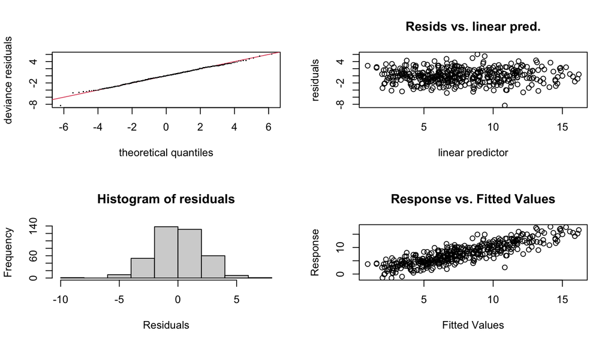

```
##
## Method: REML   Optimizer: outer newton
## full convergence after 6 iterations.
## Gradient range [-1.972997e-06,1.529068e-06]
## (score 876.5956 & scale 4.186058).
## Hessian positive definite, eigenvalue range [0.1695257,197.5771].
## Model rank =  37 / 37
##
## Basis dimension (k) checking results. Low p-value (k-index<1) may
## indicate that k is too low, especially if edf is close to k'.
##
##         k'  edf k-index p-value
## s(x0) 9.00 3.19    0.95    0.22
## s(x1) 9.00 2.78    1.02    0.66
## s(x2) 9.00 8.19    1.05    0.82
## s(x3) 9.00 1.63    0.96    0.18
```

```r
mgcv::gam.check(gam_multiple)
```

## 7.2 Interpreting `gam.check()`

The diagnostic plots show whether residuals look reasonable.

The printed output includes a check of whether the basis dimension `k` may be too low.

The `k-index` is especially useful.

A rough guide is:

- `k-index` close to 1: no obvious issue;
- low `k-index` and small p-value: `k` may be too small;
- strong residual patterns: model may be missing structure.

Diagnostics should not be interpreted mechanically. They should be combined with the plots, the model summary and the scientific question.

# 8 Plotting smooth functions

## 8.1 Base R smooth plots

The base `plot()` method for GAMs is quick and useful.

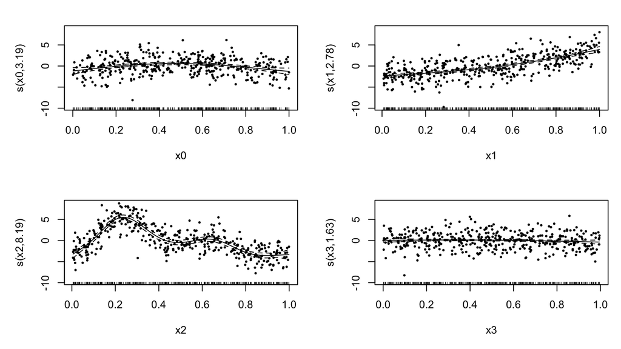

```r
plot(
  gam_multiple,
  pages = 1,
  shade = TRUE,
  residuals = TRUE,
  pch = 16,
  cex = 0.5
)
```

## 8.2 Interpreting smooth plots

Each panel shows the estimated effect of one covariate.

The y-axis is the contribution of that smooth to the fitted response.

The curve is centred around zero, so the plot shows relative changes rather than absolute predicted values.

A smooth above zero increases the predicted response relative to the average. A smooth below zero decreases it.

The shaded band shows uncertainty.

# 9 Custom prediction plots

## 9.1 Why use prediction plots?

The default smooth plots are useful for diagnostics, but custom prediction plots are often clearer for teaching and reporting.

A partial prediction plot asks:

> How does the predicted response change with one covariate, while holding the others constant?

Here we vary one covariate at a time and hold the others at their median values.

```r
make_partial_prediction <- function(variable, model, data, n = 150) {
  newdata <- data.frame(
    x0 = median(data$x0),
    x1 = median(data$x1),
    x2 = median(data$x2),
    x3 = median(data$x3)
  )

  newdata <- newdata[rep(1, n), ]
  newdata[[variable]] <- seq(
    min(data[[variable]]),
    max(data[[variable]]),
    length.out = n
  )

  pred <- predict(
    model,
    newdata = newdata,
    se.fit = TRUE
  )

  tibble(
    covariate = variable,
    value = newdata[[variable]],
    fit = as.numeric(pred$fit),
    lower = as.numeric(pred$fit - 1.96 * pred$se.fit),
    upper = as.numeric(pred$fit + 1.96 * pred$se.fit)
  )
}

partial_predictions <- purrr::map_dfr(
  c("x0", "x1", "x2", "x3"),
  make_partial_prediction,
  model = gam_multiple,
  data = gam_dat
)
```

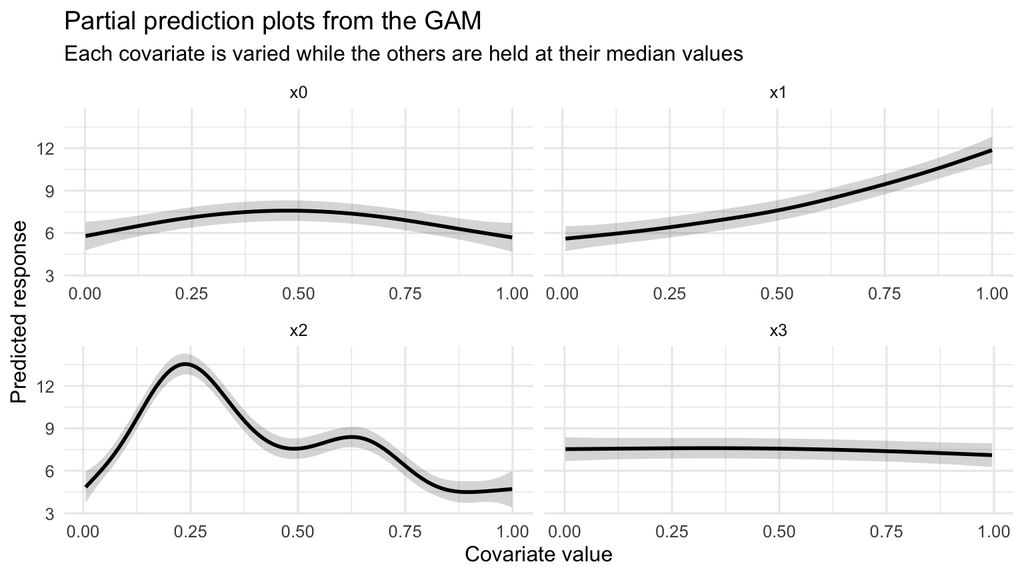

```r
ggplot(partial_predictions, aes(x = value, y = fit)) +
  geom_ribbon(aes(ymin = lower, ymax = upper), alpha = 0.2) +
  geom_line(linewidth = 1) +
  facet_wrap(~ covariate, scales = "free_x") +
  labs(
    x = "Covariate value",
    y = "Predicted response",
    title = "Partial prediction plots from the GAM",
    subtitle = "Each covariate is varied while the others are held at their median values"
  )
```

## 9.2 Interpretation

These plots show the fitted relationship between each covariate and the response.

They are usually easier to explain to applied audiences than the raw model coefficients.

For example, rather than saying that `s(x2)` has a certain EDF, we can describe the shape of the predicted response as `x2` changes.

# 10 Comparing models

## 10.1 Linear model versus GAM

For Gaussian models fitted to the same response, AIC is one useful comparison tool.

```r
AIC(
  lm_baseline,
  gam_multiple
)
```

|  | df | AIC |
| --- | --- | --- |
| lm_baseline | 6.00000 | 2050.045 |
| gam_multiple | 20.02077 | 1730.752 |

## 10.2 Interpretation

A lower AIC suggests better expected predictive performance, while penalising model complexity.

If the GAM has a much lower AIC than the linear model, this suggests that the nonlinear smooth terms improve the model.

However, AIC should not be the only criterion. We should also consider:

- whether the smooths are interpretable;
- whether diagnostics look reasonable;
- whether the model answers the scientific question;
- whether a simpler model would be easier to explain.

# 11 Prediction for new observations

## 11.1 New data

We can use the fitted GAM to predict the response for new combinations of covariates.

```r
new_observations <- tibble(
  x0 = c(0.2, 0.5, 0.8),
  x1 = c(0.2, 0.5, 0.8),
  x2 = c(0.2, 0.5, 0.8),
  x3 = c(0.2, 0.5, 0.8)
)

new_prediction_object <- predict(
  gam_multiple,
  newdata = new_observations,
  se.fit = TRUE
)

new_predictions <- new_observations %>%
  dplyr::mutate(
    fit = as.numeric(new_prediction_object$fit),
    se.fit = as.numeric(new_prediction_object$se.fit),
    lower = fit - 1.96 * se.fit,
    upper = fit + 1.96 * se.fit
  )

new_predictions
```

| x0 | x1 | x2 | x3 | fit | se.fit | lower | upper |
| --- | --- | --- | --- | --- | --- | --- | --- |
| 0.2 | 0.2 | 0.2 | 0.2 | 11.006274 | 0.3937682 | 10.234488 | 11.778059 |
| 0.5 | 0.5 | 0.5 | 0.5 | 7.589913 | 0.3719959 | 6.860801 | 8.319025 |
| 0.8 | 0.8 | 0.8 | 0.8 | 6.419603 | 0.3836290 | 5.667690 | 7.171516 |

## 11.2 Interpretation

The `fit` column gives the predicted mean response for each new observation.

The `lower` and `upper` columns give approximate 95% confidence intervals around the predicted mean.

These are useful for communicating model-based predictions.

# 12 Exercise

## 12.1 Questions

1. Remove one smooth term from the model. Does AIC change?
2. Increase `k` for `x2`. Does the EDF change much?
3. Create a partial prediction plot for only `x2`.
4. Explain the fitted effect of `x2` in one sentence for a non-statistical audience.

# 13 Exercise solution

## 13.1 1. Remove one smooth term from the model

Because `mgcv::gamSim(eg = 1)` includes one covariate with little or no true effect, a useful first choice is to remove `x3`.

We can also inspect the smooth table from the original model.

A smooth term with low EDF and a large p-value is usually weak evidence for a nonlinear relationship.

In this simulated dataset, `x3` is expected to have little influence on the response. Therefore, removing `s(x3)` should usually have little effect on model performance.

## 13.2 2. Increase `k` for `x2`

The original model used `k = 10` for all smooth terms. Here we increase only the basis dimension for `x2`.

If the EDF increases substantially and AIC improves, then the original value of `k` may have been too restrictive.

The important point is that `k` controls the maximum flexibility available to the smooth. It does not force the model to use all that flexibility.

```r
##A suitable interpretation is:

#The response changes nonlinearly with `x2`: it is not well described by a straight line, and the predicted response is highest over part of the `x2` range rather than increasing or decreasing at a constant rate.

##A slightly more ecological version would be:

##The fitted model suggests that the response varies along the `x2` gradient in a curved way, with some values of `x2` associated with higher expected responses than others.
```

## 13.5 Overall interpretation

```r
#The full GAM captures nonlinear effects of several covariates.

#The comparison with the reduced model suggests whether `x3` contributes meaningfully to the model. In this simulated dataset, `x3` is expected to have little effect, so a model without `s(x3)` may be similarly good or slightly preferable.

#Increasing `k` for `x2` checks whether the original smooth had enough flexibility. If the EDF and fitted curve do not change much, the original model was adequate.

#The partial prediction plot for `x2` is the clearest way to communicate the result. It shows that the effect of `x2` is nonlinear and should not be reduced to a single straight-line slope.
```

[output not shown]

# 14 Summary

In this practical, we fitted a GAM with several smooth covariate effects.

Key points:

- a GAM can include several smooth terms;
- each smooth represents a nonlinear effect of one covariate;
- EDF describes how flexible each smooth is;
- `k` controls the maximum flexibility available to a smooth;
- `gam.check()` helps assess diagnostics and whether `k` is adequate;
- partial prediction plots are useful for interpretation;
- AIC can help compare models fitted to the same response;
- predictions help translate the model into applied conclusions.

# 15 Link to the next document

So far the response has been Gaussian.

Next, we return to the GLM idea of non-normal responses and fit GAMs for count data and spatially structured responses.

This will show how GAMs extend naturally from linear models and GLMs to more flexible ecological and environmental models.